# Ekonometria - Projekt

Oskar Paśko

2024-05-14

# Przygotowanie zestawu danych

Nasze dane to zbiór danych 1 475 pacjentów zebrane z okresu ostatnich 12 miesięcy przez Amerykańskie Centrum Kontroli Chorobom i Zapobiegania i wyglądają następująco:

```r
library(readr)
```

```r
health <- read_csv("D:/university/6semestr/Ekonometria/projekt/health.csv")
View(health)
library(tidyverse)
glimpse(health)
```

```
## Rows: 1,475
## Columns: 9
## $ systolic <dbl> 100, 112, 134, 108, 128, 102, 126, 124, 166, 138, 118, 124, 9…
## $ weight   <dbl> 98.6, 96.9, 108.2, 84.8, 97.0, 102.4, 99.4, 53.6, 78.6, 135.5…
## $ height   <dbl> 172.0, 186.0, 154.4, 168.9, 175.3, 150.5, 157.8, 162.4, 156.9…
## $ bmi      <dbl> 33.3, 28.0, 45.4, 29.7, 31.6, 45.2, 39.9, 20.3, 31.9, 41.7, 2…
## $ waist    <dbl> 120.4, 107.8, 120.3, 109.0, 111.1, 130.7, 113.2, 74.6, 102.8,…
## $ age      <dbl> 43, 57, 38, 75, 42, 63, 58, 26, 51, 61, 47, 52, 64, 55, 72, 8…
## $ diabetes <dbl> 0, 0, 0, 0, 0, 1, 0, 0, 1, 1, 0, 0, 0, 0, 0, 0, 0, 0, 1, 0, 0…
## $ smoker   <dbl> 1, 0, 1, 0, 1, 0, 0, 1, 0, 0, 0, 1, 0, 0, 0, 1, 0, 0, 0, 1, 1…
## $ fastfood <dbl> 5, 0, 2, 1, 1, 3, 6, 5, 0, 1, 0, 3, 0, 1, 0, 5, 0, 2, 1, 3, 2…
```

```r
health <- health %>% mutate(diabetes=as.factor(diabetes)) %>%
mutate(smoker=as.factor(smoker))
```

# Analiza danych

Podsumowanie podstawowych statystyk dla zmiennych.

```r
summary(health)
```

```
##     systolic         weight           height           bmi
##  Min.   : 80.0   Min.   : 29.10   Min.   :141.2   Min.   :13.40
##  1st Qu.:114.0   1st Qu.: 69.15   1st Qu.:163.8   1st Qu.:24.10
##  Median :122.0   Median : 81.00   Median :170.3   Median :27.90
##  Mean   :124.7   Mean   : 83.56   Mean   :170.2   Mean   :28.79
##  3rd Qu.:134.0   3rd Qu.: 94.50   3rd Qu.:176.8   3rd Qu.:32.10
##  Max.   :224.0   Max.   :203.50   Max.   :200.4   Max.   :62.00
##      waist            age        diabetes smoker     fastfood
##  Min.   : 56.2   Min.   :20.00   0:1265   0:770   Min.   : 0.00
##  1st Qu.: 88.4   1st Qu.:34.00   1: 210   1:705   1st Qu.: 0.00
##  Median : 98.9   Median :49.00                    Median : 1.00
##  Mean   :100.0   Mean   :48.89                    Mean   : 2.14
##  3rd Qu.:109.5   3rd Qu.:62.00                    3rd Qu.: 3.00
##  Max.   :176.0   Max.   :80.00                    Max.   :22.00
```

Używając histogramu możemy wizualnie zobaczyć dystrybucję naszej zmiennej.

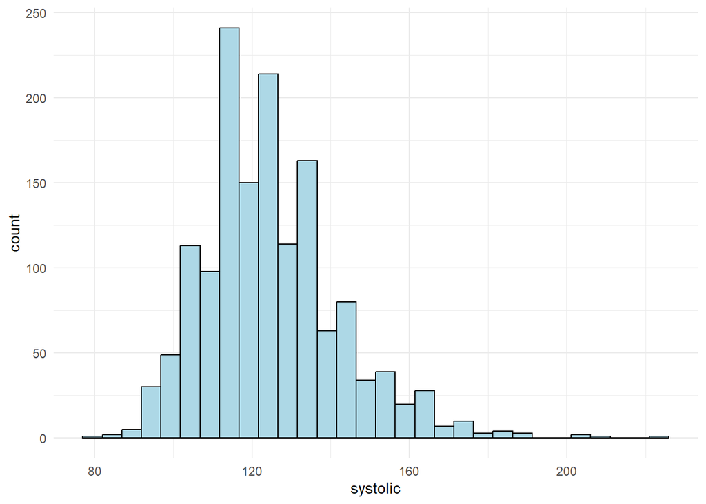

```r
health %>%
  ggplot() +
  geom_histogram(mapping = aes(x=systolic), fill= "lightblue", color= "black")+
  theme_minimal()
```

Używając zestawienia histogramów możemy spojrzeć na dystrybucję naszych innych zmiennych.

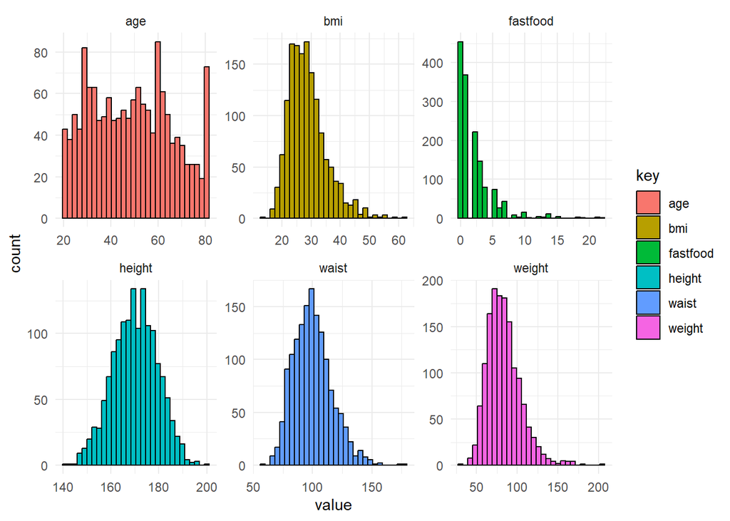

```r
health %>%
  select(-systolic) %>%
  keep(is.numeric) %>%
  gather() %>%
  ggplot() +
  geom_histogram(mapping = aes(x=value, fill=key), color="black") + facet_wrap(~ key, scales = "free") +
  theme_minimal()
```

W następnym kroku sprawdzimy korelację pomiędzy zmiennymi.

```r
cor(health[, c("systolic", "weight", "height", "bmi", "waist", "age", "fastfood")])
```

```
##             systolic      weight      height         bmi       waist
## systolic  1.00000000  0.10021386  0.02301030  0.09054668  0.16813021
## weight    0.10021386  1.00000000  0.40622019  0.89152826  0.89928820
## height    0.02301030  0.40622019  1.00000000 -0.03848241  0.14544676
## bmi       0.09054668  0.89152826 -0.03848241  1.00000000  0.91253710
## waist     0.16813021  0.89928820  0.14544676  0.91253710  1.00000000
## age       0.40170911 -0.02217221 -0.12656952  0.03379844  0.19508769
## fastfood -0.08417538  0.05770725  0.10917107  0.01003525 -0.02167324
##                  age    fastfood
## systolic  0.40170911 -0.08417538
## weight   -0.02217221  0.05770725
## height   -0.12656952  0.10917107
## bmi       0.03379844  0.01003525
## waist     0.19508769 -0.02167324
## age       1.00000000 -0.30089756
## fastfood -0.30089756  1.00000000
```

# Dopasowanie modelu regresji liniowej

Używamy zmiennej ‘age’, która ma największe powiązanie z zmienna decyzyjną, jako predykator oraz ‘systolic’.

```r
health_mod1 <- lm(data = health, systolic~age)
summary(health_mod1)
```

```
##
## Call:
## lm(formula = systolic ~ age, data = health)
##
## Residuals:
##     Min      1Q  Median      3Q     Max
## -42.028 -10.109  -1.101   8.223  98.806
##
## Coefficients:
##              Estimate Std. Error t value Pr(>|t|)
## (Intercept) 104.34474    1.28169   81.41   <2e-16 ***
## age           0.41698    0.02477   16.84   <2e-16 ***
## ---
## Signif. codes:  0 '***' 0.001 '**' 0.01 '*' 0.05 '.' 0.1 ' ' 1
##
## Residual standard error: 16.14 on 1473 degrees of freedom
## Multiple R-squared:  0.1614, Adjusted R-squared:  0.1608
## F-statistic: 283.4 on 1 and 1473 DF,  p-value: < 2.2e-16
```

Dodajemy wszystkie zmienne do naszego modelu.

```r
health_mod2 <- lm(data = health, systolic~.)
summary(health_mod2)
```

```
##
## Call:
## lm(formula = systolic ~ ., data = health)
##
## Residuals:
##     Min      1Q  Median      3Q     Max
## -41.463 -10.105  -0.765   8.148 100.398
##
## Coefficients:
##              Estimate Std. Error t value Pr(>|t|)
## (Intercept) 163.30026   33.52545   4.871 1.23e-06 ***
## weight        0.55135    0.19835   2.780  0.00551 **
## height       -0.39201    0.19553  -2.005  0.04516 *
## bmi          -1.36839    0.57574  -2.377  0.01759 *
## waist        -0.00955    0.08358  -0.114  0.90905
## age           0.43345    0.03199  13.549  < 2e-16 ***
## diabetes1     2.20636    1.26536   1.744  0.08143 .
## smoker1       1.13983    0.90964   1.253  0.21039
## fastfood      0.17638    0.15322   1.151  0.24985
## ---
## Signif. codes:  0 '***' 0.001 '**' 0.01 '*' 0.05 '.' 0.1 ' ' 1
##
## Residual standard error: 15.99 on 1466 degrees of freedom
## Multiple R-squared:  0.1808, Adjusted R-squared:  0.1763
## F-statistic: 40.44 on 8 and 1466 DF,  p-value: < 2.2e-16
```

Pierwszym testem jest test na zerowe średnie reszt.

```r
mean(health_mod2$residuals)
```

```
## [1] -8.500251e-16
```

Nasza średnia jest bliska 0, wieć przechodzimy do testu normalności reszt.

```r
library(olsrr)
```

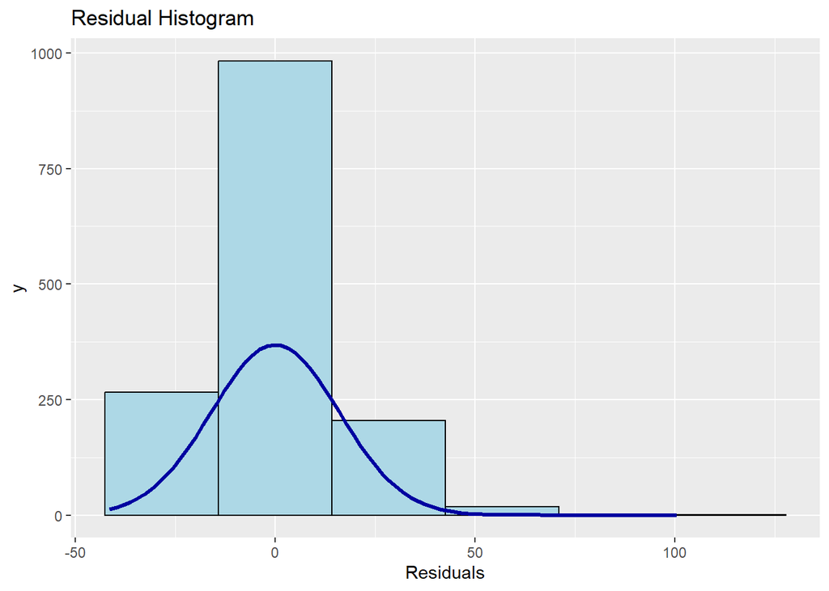

```r
ols_plot_resid_hist(health_mod2)
```

Teraz test heteroskedatyczności naszych reszt.

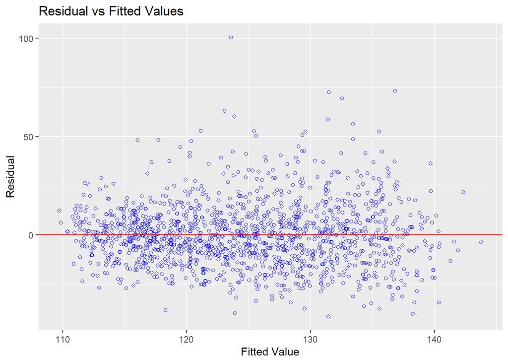

```r
ols_plot_resid_fit(health_mod2)
```

Następny test to autokorelacja reszt.

```r
library(car)
durbinWatsonTest(health_mod2)
```

```
##  lag Autocorrelation D-W Statistic p-value
##    1     -0.01985291      2.038055   0.436
##  Alternative hypothesis: rho != 0
```

Test na wysąpienie punktów wplywowych w naszych danych.

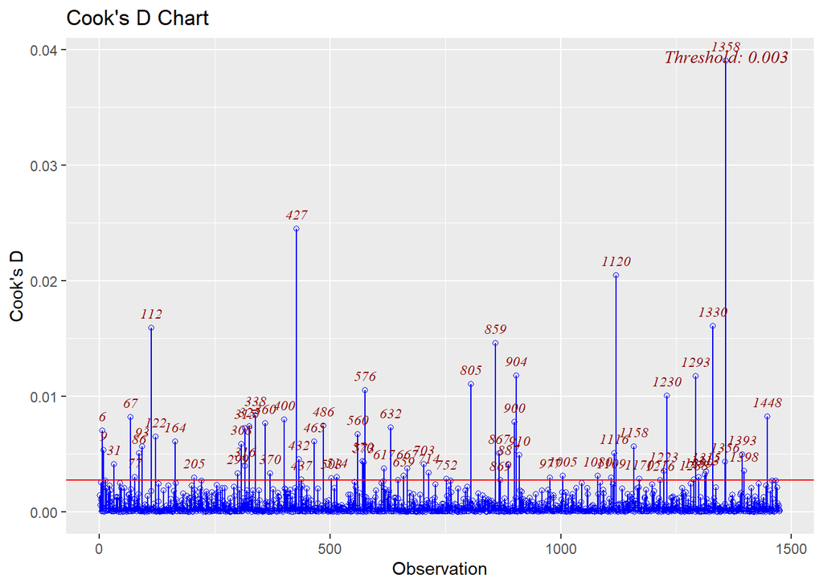

```r
cooks_plot <- ols_plot_cooksd_chart(health_mod2)
```

```r
cooks_plot$outliers[,"obserbation"]
```

[output not shown]

Według wykresu obserwacja 1358 odstaje od reszty, więc się jej przyjrzymy.

```r
health[1358,]
```

```
## # A tibble: 1 × 9
##   systolic weight height   bmi waist   age diabetes smoker fastfood
##      <dbl>  <dbl>  <dbl> <dbl> <dbl> <dbl> <fct>    <fct>     <dbl>
## 1      184   146.   180.  44.9  140.    26 0        0            14
```

Porównanie do całego zestawu statystyk.

```r
summary(health)
```

```
##     systolic         weight           height           bmi
##  Min.   : 80.0   Min.   : 29.10   Min.   :141.2   Min.   :13.40
##  1st Qu.:114.0   1st Qu.: 69.15   1st Qu.:163.8   1st Qu.:24.10
##  Median :122.0   Median : 81.00   Median :170.3   Median :27.90
##  Mean   :124.7   Mean   : 83.56   Mean   :170.2   Mean   :28.79
##  3rd Qu.:134.0   3rd Qu.: 94.50   3rd Qu.:176.8   3rd Qu.:32.10
##  Max.   :224.0   Max.   :203.50   Max.   :200.4   Max.   :62.00
##      waist            age        diabetes smoker     fastfood
##  Min.   : 56.2   Min.   :20.00   0:1265   0:770   Min.   : 0.00
##  1st Qu.: 88.4   1st Qu.:34.00   1: 210   1:705   1st Qu.: 0.00
##  Median : 98.9   Median :49.00                    Median : 1.00
##  Mean   :100.0   Mean   :48.89                    Mean   : 2.14
##  3rd Qu.:109.5   3rd Qu.:62.00                    3rd Qu.: 3.00
##  Max.   :176.0   Max.   :80.00                    Max.   :22.00
```

Tworzymy listę wszystkich odstających obserwacji.

```r
cooksd <- cooks.distance(health_mod2)
outliers_index <- as.numeric(unlist(which(cooksd > 4/length(cooksd))))
outliers_index
```

```
##  [1]    6    9   31   67   77   86   93  112  122  164  205  299  308  315  316
## [16]  325  338  360  370  400  427  432  437  465  486  503  514  560  570  573
## [31]  576  617  632  659  667  703  714  752  805  859  867  869  887  900  904
## [46]  910  977 1005 1080 1109 1116 1120 1158 1170 1216 1223 1230 1288 1293 1299
## [61] 1313 1315 1330 1356 1358 1393 1398 1448
```

Porównujemy odstające obserwacje z pozostałymi wartościami.

```r
summary(health[outliers_index,])
```

```
##     systolic         weight           height           bmi
##  Min.   : 86.0   Min.   : 29.10   Min.   :144.2   Min.   :13.40
##  1st Qu.:109.0   1st Qu.: 68.92   1st Qu.:159.5   1st Qu.:23.60
##  Median :163.0   Median : 82.20   Median :167.2   Median :32.00
##  Mean   :149.4   Mean   : 91.73   Mean   :167.2   Mean   :32.26
##  3rd Qu.:174.0   3rd Qu.:109.03   3rd Qu.:174.2   3rd Qu.:38.42
##  Max.   :224.0   Max.   :203.50   Max.   :193.3   Max.   :62.00
##      waist             age        diabetes smoker    fastfood
##  Min.   : 56.20   Min.   :21.00   0:44     0:29   Min.   : 0.000
##  1st Qu.: 92.35   1st Qu.:41.75   1:24     1:39   1st Qu.: 0.000
##  Median :111.20   Median :56.00                   Median : 1.000
##  Mean   :109.81   Mean   :55.50                   Mean   : 2.897
##  3rd Qu.:124.92   3rd Qu.:68.00                   3rd Qu.: 3.000
##  Max.   :172.20   Max.   :80.00                   Max.   :18.000
```

```r
summary(health[-outliers_index,])
```

```
##     systolic         weight           height           bmi
##  Min.   : 80.0   Min.   : 41.10   Min.   :141.2   Min.   :16.00
##  1st Qu.:114.0   1st Qu.: 69.15   1st Qu.:164.0   1st Qu.:24.10
##  Median :122.0   Median : 81.00   Median :170.4   Median :27.80
##  Mean   :123.5   Mean   : 83.17   Mean   :170.3   Mean   :28.63
##  3rd Qu.:134.0   3rd Qu.: 94.10   3rd Qu.:176.8   3rd Qu.:31.90
##  Max.   :182.0   Max.   :180.20   Max.   :200.4   Max.   :59.00
##      waist             age        diabetes smoker     fastfood
##  Min.   : 65.60   Min.   :20.00   0:1221   0:741   Min.   : 0.000
##  1st Qu.: 88.15   1st Qu.:34.00   1: 186   1:666   1st Qu.: 0.000
##  Median : 98.50   Median :48.00                    Median : 1.000
##  Mean   : 99.56   Mean   :48.57                    Mean   : 2.103
##  3rd Qu.:108.80   3rd Qu.:62.00                    3rd Qu.: 3.000
##  Max.   :176.00   Max.   :80.00                    Max.   :22.000
```

Teraz aby ulepszyć nasz model usuwamy nasze wartości odstające ze zbioru danych. Jednak aby odnosić się do oryginalnych danych musimy zrobić nowy zbiór.

```r
health2 <- health[-outliers_index,]
ols_vif_tol(health_mod2)
```

```
##   Variables  Tolerance       VIF
## 1    weight 0.01041041 96.057711
## 2    height 0.05217187 19.167417
## 3       bmi 0.01250176 79.988712
## 4     waist 0.09518197 10.506192
## 5       age 0.58828067  1.699869
## 6 diabetes1 0.88685760  1.127577
## 7   smoker1 0.83978882  1.190776
## 8  fastfood 0.89558690  1.116586
```

Budujemy nowy model regresji liniowej.

```r
health_mod3 <- lm(data=health2, systolic ~ weight+age+diabetes)
summary(health_mod3)
```

```
##
## Call:
## lm(formula = systolic ~ weight + age + diabetes, data = health2)
##
## Residuals:
##     Min      1Q  Median      3Q     Max
## -38.825  -9.004  -0.177   8.222  49.679
##
## Coefficients:
##             Estimate Std. Error t value Pr(>|t|)
## (Intercept) 96.62591    1.93014  50.062  < 2e-16 ***
## weight       0.09535    0.01870   5.100 3.87e-07 ***
## age          0.38372    0.02218  17.297  < 2e-16 ***
## diabetes1    2.62446    1.11859   2.346   0.0191 *
## ---
## Signif. codes:  0 '***' 0.001 '**' 0.01 '*' 0.05 '.' 0.1 ' ' 1
##
## Residual standard error: 13.59 on 1403 degrees of freedom
## Multiple R-squared:  0.2128, Adjusted R-squared:  0.2111
## F-statistic: 126.4 on 3 and 1403 DF,  p-value: < 2.2e-16
```

```r
health2 <- health2 %>%
mutate(age=age,
lage=log(age))
```

Budujemy nasz kolejny model używając poniższej funkcji.

```r
ols_step_both_p(
model = lm(
data = health2,
systolic ~ weight * diabetes + age * diabetes + age * diabetes + lage * diabetes
),
pent = 0.2,
prem = 0.01,
details = FALSE
)
```

```
##
##
##                                    Stepwise Summary
## -------------------------------------------------------------------------------------
## Step    Variable                AIC          SBC         SBIC        R2       Adj. R2
## -------------------------------------------------------------------------------------
##  0      Base Model           11672.391    11682.890    7675.555    0.00000    0.00000
##  1      age (+)              11372.782    11388.530    7373.984    0.19294    0.19237
##  2      weight (+)           11345.207    11366.204    7344.435    0.20973    0.20861
##  3      lage (+)             11337.570    11363.816    7334.823    0.21513    0.21345
##  4      diabetes:lage (+)    11334.109    11365.605    7329.387    0.21817    0.21594
## -------------------------------------------------------------------------------------
##
## Final Model Output
## ------------------
##
##                           Model Summary
## ------------------------------------------------------------------
## R                        0.467       RMSE                  13.525
## R-Squared                0.218       MSE                  183.583
## Adj. R-Squared           0.216       Coef. Var             10.968
## Pred R-Squared           0.213       AIC                11334.109
## MAE                     10.622       SBC                11365.605
## ------------------------------------------------------------------
##  RMSE: Root Mean Square Error
##  MSE: Mean Square Error
##  MAE: Mean Absolute Error
##  AIC: Akaike Information Criteria
##  SBC: Schwarz Bayesian Criteria
##
##                                  ANOVA
## ------------------------------------------------------------------------
##                   Sum of
##                  Squares          DF    Mean Square      F         Sig.
## ------------------------------------------------------------------------
## Regression     71821.677           4      17955.419    97.805    0.0000
## Residual      257383.883        1402        183.583
## Total         329205.561        1406
## ------------------------------------------------------------------------
##
##                                      Parameter Estimates
## ----------------------------------------------------------------------------------------------
##          model       Beta    Std. Error    Std. Beta      t        Sig       lower      upper
## ----------------------------------------------------------------------------------------------
##    (Intercept)    141.696        14.785                  9.584    0.000    112.692    170.699
##            age      0.742         0.119        0.822     6.224    0.000      0.508      0.976
##         weight      0.100         0.019        0.128     5.346    0.000      0.063      0.137
##           lage    -16.473         5.364       -0.405    -3.071    0.002    -26.996     -5.950
## lage:diabetes1      0.642         0.275        0.058     2.335    0.020      0.103      1.182
## ----------------------------------------------------------------------------------------------
```